# A_Study_of_housing_price_in_Beijing

## A Study of Housing price in Beijing

Project follows the CRISP-DM process outlined for questions, by Yu ZHANG

```python
#import libraries
import numpy as np
import pandas as pd
import matplotlib.pyplot as plt
import seaborn as sns
from datetime import datetime
from sklearn.metrics import r2_score, mean_squared_error

from sklearn.svm import LinearSVR, SVR
from sklearn.base import BaseEstimator, TransformerMixin
from sklearn.preprocessing import OneHotEncoder, StandardScaler
from sklearn.pipeline import Pipeline, FeatureUnion
from sklearn.model_selection import GridSearchCV, train_test_split
import random
```

### Business Understanding

The Beijing housing market is highly important to the people and leaders of Beijing, and recently the housing price is increasing at a tremendous speed. As to be a Chinese, I am quite anxious on this market in the capital of China.

With the housing price data of Beijing from 2011 to 2017, we will at first have a study with main focus on the following questions:

1. Which factors influence price the greatest?
2. The price increases at which speed?

Then we will try to build a model to forecast the housing price in Beijing, and compare the result with the real result with RMSE(Root mean squared error) as the metric to measure our model.

With these studies may provide some advice to help people have a better understanding of the market in Beijing, and make decisions. And may also help the Chinese government to control the market more efficiently.

### Data Understanding

```python
#load dataset
housing = pd.read_csv('Data/data.csv', sep=',', encoding='iso-8859-1')
```

```python
housing.info()
```

```
<class 'pandas.core.frame.DataFrame'>
RangeIndex: 318851 entries, 0 to 318850
Data columns (total 26 columns):
url                    318851 non-null object
id                     318851 non-null object
Lng                    318851 non-null float64
Lat                    318851 non-null float64
Cid                    318851 non-null int64
tradeTime              318851 non-null object
DOM                    160874 non-null float64
followers              318851 non-null int64
totalPrice             318851 non-null float64
price                  318851 non-null int64
square                 318851 non-null float64
livingRoom             318851 non-null object
drawingRoom            318851 non-null object
kitchen                318851 non-null int64
bathRoom               318851 non-null object
floor                  318851 non-null object
buildingType           316830 non-null float64
constructionTime       318851 non-null object
renovationCondition    318851 non-null int64
buildingStructure      318851 non-null int64
ladderRatio            318851 non-null float64
elevator               318819 non-null float64
fiveYearsProperty      318819 non-null float64
subway                 318819 non-null float64
district               318851 non-null int64
communityAverage       318388 non-null float64
dtypes: float64(11), int64(7), object(8)
memory usage: 63.2+ MB
```

Here, according to the Kaggle data context:

1. url: the url which fetches the data
2. id: the id of transaction
3. Lng: and Lat coordinates, using the BD09 protocol.
4. Cid: community id
5. tradeTime: the time of transaction
6. DOM: active days on market.Know more in https://en.wikipedia.org/wiki/Days_on_market
7. followers: the number of people follow the transaction.
8. totalPrice: the total price
9. price: the average price by square
10. square: the square of house
11. livingRoom: the number of living room
12. drawingRoom: the number of drawing room
13. kitchen: the number of kitchen
14. bathroom the number of bathroom
15. floor: the height of the house.
16. buildingType: including tower( 1 ) , bungalow( 2 )，combination of plate and tower( 3 ), plate( 4 ).
17. constructionTime: the time of construction
18. renovationCondition: including other( 1 ), rough( 2 ),Simplicity( 3 ), hardcover( 4 )
19. buildingStructure: including unknow( 1 ), mixed( 2 ), brick and wood( 3 ), brick and concrete( 4 ),steel( 5 ) and steel-concrete composite ( 6 ).
20. ladderRatio: the proportion between number of residents on the same floor and number of elevator of ladder. It describes how many ladders a resident have on average.
21. elevator have ( 1 ) or not have elevator( 0 )
22. fiveYearsProperty: if the owner have the property for less than 5 years

```python
housing.head()
```

|  | url | id | Lng | Lat | Cid | tradeTime | DOM | followers | totalPrice | price | ... | buildingType | constructionTime | renovationCondition | buildingStructure | ladderRatio | elevator | fiveYearsProperty | subway | district | communityAverage |
| --- | --- | --- | --- | --- | --- | --- | --- | --- | --- | --- | --- | --- | --- | --- | --- | --- | --- | --- | --- | --- | --- |
| 0 | https://bj.lianjia.com/chengjiao/101084782030.... | 101084782030 | 116.475489 | 40.019520 | 1111027376244 | 2016-08-09 | 1464.0 | 106 | 415.0 | 31680 | ... | 1.0 | 2005 | 3 | 6 | 0.217 | 1.0 | 0.0 | 1.0 | 7 | 56021.0 |
| 1 | https://bj.lianjia.com/chengjiao/101086012217.... | 101086012217 | 116.453917 | 39.881534 | 1111027381879 | 2016-07-28 | 903.0 | 126 | 575.0 | 43436 | ... | 1.0 | 2004 | 4 | 6 | 0.667 | 1.0 | 1.0 | 0.0 | 7 | 71539.0 |
| 2 | https://bj.lianjia.com/chengjiao/101086041636.... | 101086041636 | 116.561978 | 39.877145 | 1111040862969 | 2016-12-11 | 1271.0 | 48 | 1030.0 | 52021 | ... | 4.0 | 2005 | 3 | 6 | 0.500 | 1.0 | 0.0 | 0.0 | 7 | 48160.0 |
| 3 | https://bj.lianjia.com/chengjiao/101086406841.... | 101086406841 | 116.438010 | 40.076114 | 1111043185817 | 2016-09-30 | 965.0 | 138 | 297.5 | 22202 | ... | 1.0 | 2008 | 1 | 6 | 0.273 | 1.0 | 0.0 | 0.0 | 6 | 51238.0 |
| 4 | https://bj.lianjia.com/chengjiao/101086920653.... | 101086920653 | 116.428392 | 39.886229 | 1111027381174 | 2016-08-28 | 927.0 | 286 | 392.0 | 48396 | ... | 4.0 | 1960 | 2 | 2 | 0.333 | 0.0 | 1.0 | 1.0 | 1 | 62588.0 |

5 rows × 26 columns

We will build a map to have a general idea:

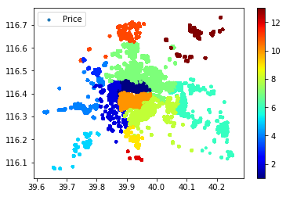

```python
fig = plt.scatter(x=housing['Lat'], y=housing['Lng'], s=10, label='Price', \
    c=housing['district'], cmap=plt.get_cmap('jet'))
plt.colorbar(fig)
plt.legend()
plt.show()
```

### Prepare Data

Some data preparation steps need to be done before using the dataset for exploration, including：

1. Drop the following columns: 'url', 'id', 'price', 'Cid', 'DOM', 'followers', 'communityAverage'
2. Drop polluted rows on 'livingRoom', 'drawingRoom', 'bathRoom', 'constructionTime'
3. Drop NA rows in 'buildingType'
4. Format data

```python
#1. Drop the following columns: 'url', 'id', 'price', 'Cid', 'DOM', 'followers', 'communityAverage'
housing = housing.drop(['url','id','price','Cid','DOM', 'followers', 'communityAverage'], axis=1)
housing.head()
```

|  | Lng | Lat | tradeTime | totalPrice | square | livingRoom | drawingRoom | kitchen | bathRoom | floor | buildingType | constructionTime | renovationCondition | buildingStructure | ladderRatio | elevator | fiveYearsProperty | subway | district |
| --- | --- | --- | --- | --- | --- | --- | --- | --- | --- | --- | --- | --- | --- | --- | --- | --- | --- | --- | --- |
| 0 | 116.475489 | 40.019520 | 2016-08-09 | 415.0 | 131.00 | 2 | 1 | 1 | 1 | ¸ß 26 | 1.0 | 2005 | 3 | 6 | 0.217 | 1.0 | 0.0 | 1.0 | 7 |
| 1 | 116.453917 | 39.881534 | 2016-07-28 | 575.0 | 132.38 | 2 | 2 | 1 | 2 | ¸ß 22 | 1.0 | 2004 | 4 | 6 | 0.667 | 1.0 | 1.0 | 0.0 | 7 |
| 2 | 116.561978 | 39.877145 | 2016-12-11 | 1030.0 | 198.00 | 3 | 2 | 1 | 3 | ÖÐ 4 | 4.0 | 2005 | 3 | 6 | 0.500 | 1.0 | 0.0 | 0.0 | 7 |
| 3 | 116.438010 | 40.076114 | 2016-09-30 | 297.5 | 134.00 | 3 | 1 | 1 | 1 | µ× 21 | 1.0 | 2008 | 1 | 6 | 0.273 | 1.0 | 0.0 | 0.0 | 6 |
| 4 | 116.428392 | 39.886229 | 2016-08-28 | 392.0 | 81.00 | 2 | 1 | 1 | 1 | ÖÐ 6 | 4.0 | 1960 | 2 | 2 | 0.333 | 0.0 | 1.0 | 1.0 | 1 |

```python
housing.info()
```

```
<class 'pandas.core.frame.DataFrame'>
RangeIndex: 318851 entries, 0 to 318850
Data columns (total 19 columns):
Lng                    318851 non-null float64
Lat                    318851 non-null float64
tradeTime              318851 non-null object
totalPrice             318851 non-null float64
square                 318851 non-null float64
livingRoom             318851 non-null object
drawingRoom            318851 non-null object
kitchen                318851 non-null int64
bathRoom               318851 non-null object
floor                  318851 non-null object
buildingType           316830 non-null float64
constructionTime       318851 non-null object
renovationCondition    318851 non-null int64
buildingStructure      318851 non-null int64
ladderRatio            318851 non-null float64
elevator               318819 non-null float64
fiveYearsProperty      318819 non-null float64
subway                 318819 non-null float64
district               318851 non-null int64
dtypes: float64(9), int64(4), object(6)
memory usage: 46.2+ MB
```

```python
#2. Drop polluated rows
# At first, we would like to see the polluated data:
print("livingRoom:" + str(housing['livingRoom'].unique()))
print("drawingRoom:" + str(housing['drawingRoom'].unique()))
print("bathRoom:" + str(housing['bathRoom'].unique()))
print("constructionTime:" + str(housing['constructionTime'].unique()))
```

```
livingRoom:[2 3 1 4 5 6 9 0 7 8 '1' '4' '3' '2' '5' '7' '9' '6' '0' '#NAME?' '8']
drawingRoom:[1 2 0 4 3 5 '0' '1' '2' '3' '4' 'ÖÐ 14' 'ÖÐ 15' 'ÖÐ 16' 'ÖÐ 6' '¸ß 14'
 '¶¥ 6' 'µÍ 6' 'µÍ 16' '¸ß 12' 'µÍ 15' '5' '¸ß 6' 'µ× 28' 'µ× 11' 'ÖÐ 24'
 'µ× 20' 'ÖÐ 22']
bathRoom:[1 2 3 0 4 5 6 7 2006 2003 1990 2000 1996 2005 2011 '1' '2' '0' '3' '4'
 '5' 'Î´Öª' 1994 2004 '2003' '7']
constructionTime:['2005' '2004' '2008' '1960' '1997' '2009' '2006' '1991' '2001' '1990'
 '2011' '2000' '1998' '2010' '1996' '1993' '2002' 'Î´Öª' '2012' '1989'
 '2003' '2007' '1994' '1984' '1992' '2014' '1985' '2013' '1999' '1979'
 '1981' '1976' '1982' '1975' '1983' '1986' '1995' '1965' '1988' '1987'
 '2015' '1955' '1980' '1978' '1958' '1970' '1956' '1977' '1964' '1963'
 '1967' '2016' '1974' '1973' '1959' '1954' '1962' '1966' '1957' '1944'
 '1972' '1971' '1953' '1968' '1961' '1950' '1952' '1933' '1969' '1' '0'
 '1906' '1934' '1914']
```

```python
housing = housing[housing.livingRoom != '#NAME?']
```

```python
print("livingRoom:" + str(housing['livingRoom'].unique()))
print("drawingRoom:" + str(housing['drawingRoom'].unique()))
print("bathRoom:" + str(housing['bathRoom'].unique()))
print("constructionTime:" + str(housing['constructionTime'].unique()))
```

```
livingRoom:[2 3 1 4 5 6 9 0 7 8 '1' '4' '3' '2' '5' '7' '9' '6' '0' '8']
drawingRoom:[1 2 0 4 3 5 '0' '1' '2' '3' '4' '5']
bathRoom:[1 2 3 0 4 5 6 7 '1' '2' '0' '3' '4' '5' '7']
constructionTime:['2005' '2004' '2008' '1960' '1997' '2009' '2006' '1991' '2001' '1990'
 '2011' '2000' '1998' '2010' '1996' '1993' '2002' 'Î´Öª' '2012' '1989'
 '2003' '2007' '1994' '1984' '1992' '2014' '1985' '2013' '1999' '1979'
 '1981' '1976' '1982' '1975' '1983' '1986' '1995' '1965' '1988' '1987'
 '2015' '1955' '1980' '1978' '1958' '1970' '1956' '1977' '1964' '1963'
 '1967' '2016' '1974' '1973' '1959' '1954' '1962' '1966' '1957' '1944'
 '1972' '1971' '1953' '1968' '1961' '1950' '1952' '1933' '1969' '1906'
 '1934' '1914']
```

```python
housing = housing[housing.constructionTime != 'Î´Öª']
```

```python
print("livingRoom:" + str(housing['livingRoom'].unique()))
print("drawingRoom:" + str(housing['drawingRoom'].unique()))
print("bathRoom:" + str(housing['bathRoom'].unique()))
print("constructionTime:" + str(housing['constructionTime'].unique()))
```

```
livingRoom:[2 3 1 4 5 6 9 0 7 8 '1' '3' '4' '2' '5' '7' '9' '6' '0' '8']
drawingRoom:[1 2 0 4 3 5 '0' '1' '2' '3' '4' '5']
bathRoom:[1 2 3 0 4 5 6 7 '1' '2' '0' '3' '4' '5' '7']
constructionTime:['2005' '2004' '2008' '1960' '1997' '2009' '2006' '1991' '2001' '1990'
 '2011' '2000' '1998' '2010' '1996' '1993' '2002' '2012' '1989' '2003'
 '2007' '1994' '1984' '1992' '2014' '1985' '2013' '1999' '1979' '1981'
 '1976' '1982' '1975' '1983' '1986' '1995' '1965' '1988' '1987' '2015'
 '1955' '1980' '1978' '1958' '1970' '1956' '1977' '1964' '1963' '1967'
 '2016' '1974' '1973' '1959' '1954' '1962' '1966' '1957' '1944' '1972'
 '1971' '1953' '1968' '1961' '1950' '1952' '1933' '1969' '1906' '1934'
 '1914']
```

```python
housing.info()
```

```
<class 'pandas.core.frame.DataFrame'>
Int64Index: 299536 entries, 0 to 318849
Data columns (total 19 columns):
Lng                    299536 non-null float64
Lat                    299536 non-null float64
tradeTime              299536 non-null object
totalPrice             299536 non-null float64
square                 299536 non-null float64
livingRoom             299536 non-null object
drawingRoom            299536 non-null object
kitchen                299536 non-null int64
bathRoom               299536 non-null object
floor                  299536 non-null object
buildingType           297990 non-null float64
constructionTime       299536 non-null object
renovationCondition    299536 non-null int64
buildingStructure      299536 non-null int64
ladderRatio            299536 non-null float64
elevator               299536 non-null float64
fiveYearsProperty      299536 non-null float64
subway                 299536 non-null float64
district               299536 non-null int64
dtypes: float64(9), int64(4), object(6)
memory usage: 45.7+ MB
```

```python
#3 Drop NA rows in 'buildingType'
housing = housing.dropna(subset=['buildingType'], axis=0)
```

```python
housing['livingRoom'] = housing['livingRoom'].astype('int64')
housing['drawingRoom'] = housing['drawingRoom'].astype('int64')
housing['bathRoom'] = housing['bathRoom'].astype('int64')
housing['constructionTime'] = housing['constructionTime'].astype('int64')
```

```python
housing.info()
```

```
<class 'pandas.core.frame.DataFrame'>
Int64Index: 297990 entries, 0 to 318849
Data columns (total 19 columns):
Lng                    297990 non-null float64
Lat                    297990 non-null float64
tradeTime              297990 non-null object
totalPrice             297990 non-null float64
square                 297990 non-null float64
livingRoom             297990 non-null int64
drawingRoom            297990 non-null int64
kitchen                297990 non-null int64
bathRoom               297990 non-null int64
floor                  297990 non-null object
buildingType           297990 non-null float64
constructionTime       297990 non-null int64
renovationCondition    297990 non-null int64
buildingStructure      297990 non-null int64
ladderRatio            297990 non-null float64
elevator               297990 non-null float64
fiveYearsProperty      297990 non-null float64
subway                 297990 non-null float64
district               297990 non-null int64
dtypes: float64(9), int64(8), object(2)
memory usage: 45.5+ MB
```

```python
housing.isnull().sum()
```

```
Lng                    0
Lat                    0
tradeTime              0
totalPrice             0
square                 0
livingRoom             0
drawingRoom            0
kitchen                0
bathRoom               0
floor                  0
buildingType           0
constructionTime       0
renovationCondition    0
buildingStructure      0
ladderRatio            0
elevator               0
fiveYearsProperty      0
subway                 0
district               0
dtype: int64
```

Here, we have finally a clean data.

### Answer Questions base on dataset

Now our data is ready! We can use this dataset to study our questions:

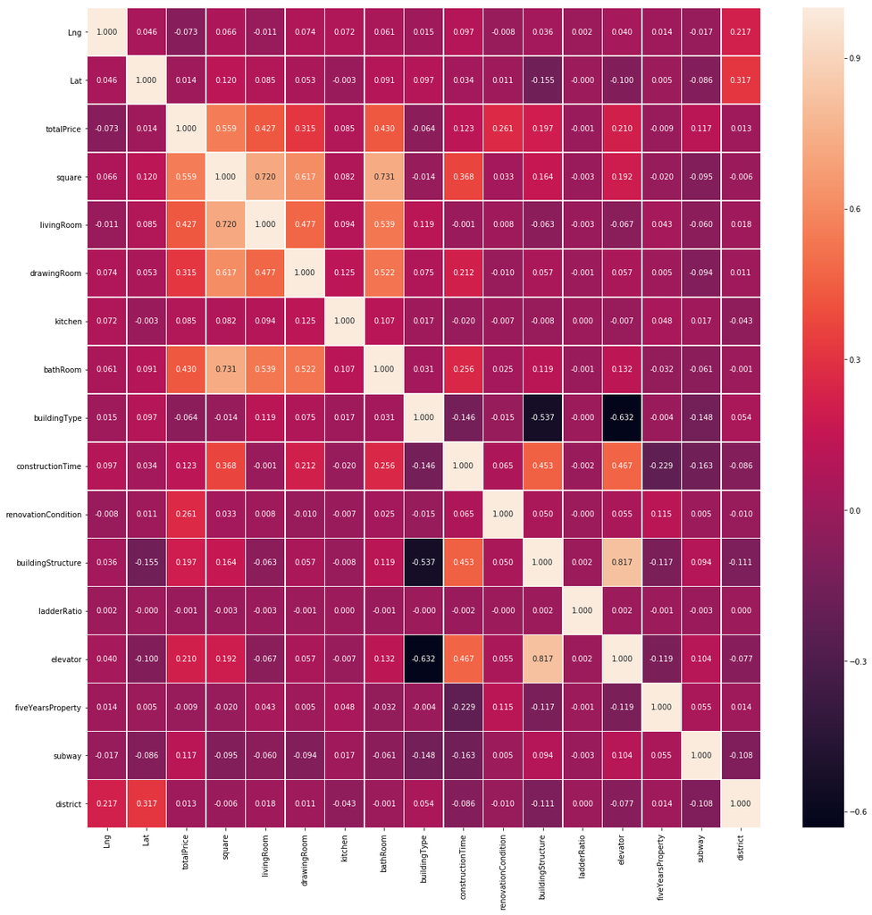

```python
# Question 1: Which factors influence price the greatest?
f,ax = plt.subplots(figsize=(20, 20))
sns.heatmap(housing.corr(), annot = True, linewidth = .5, fmt = ".3f")
plt.show()
```

In general, the bigger the house is, its price is more expensive, it's quite normal.

```python
# Question 2: The price increases at which speed?
housing['tradeTime'] = housing['tradeTime'].astype('datetime64[ns]')
housing['tradeTime'].head()
```

```
0   2016-08-09
1   2016-07-28
2   2016-12-11
3   2016-09-30
4   2016-08-28
Name: tradeTime, dtype: datetime64[ns]
```

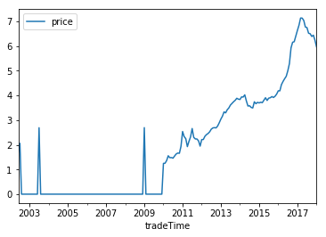

```python
price_by_trade_time = pd.DataFrame()
price_by_trade_time['price'] = housing['totalPrice']/housing['square']
price_by_trade_time.index = housing['tradeTime'].astype('datetime64[ns]')
price_by_trade_month = price_by_trade_time.resample('M').mean().to_period('M').fillna(0)
price_by_trade_month.plot(kind='line')
plt.show()
```

It seems that we have too much data missing before 2010, so we will only concentrate on data after 2010.

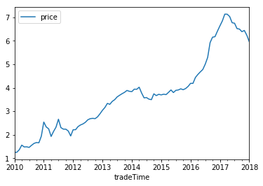

```python
price_by_trade_month = price_by_trade_month[price_by_trade_month.index > datetime(2009, 12, 31)]
price_by_trade_month.plot(kind='line')
plt.show()
```

```python
print(price_by_trade_month.head())
print(price_by_trade_month.tail())
```

```
              price
tradeTime
2010-01    1.246596
2010-02    1.252939
2010-03    1.361642
2010-04    1.556305
2010-05    1.477994
              price
tradeTime
2017-09    6.501421
2017-10    6.391181
2017-11    6.442123
2017-12    6.241992
2018-01    5.966570
```

Suppose that the price in 2010-01 and 2010-02 are the same, we can have a simple computation that the geometric average growth rate from 2010 to 2018 is about:

```python
average_growth_rate = (5.966570/1.252939) ** (1/8) - 1
```

```python
print("The geometric average growth rate from 2010 to 2018 is about " + str(average_growth_rate*100) +'%')
```

```
The geometric average growth rate from 2010 to 2018 is about 21.541432746404098%
```

Well, that is a quite tremendous speed, investment in the real estate is good idea in this period!

### Build model to forcast the housing price in Beijing

As we can see from the previous result, we have much data missing before 2010, the data before 2010 may cause outlier problem, we should better not use them.

```python
housing = housing[housing.tradeTime >  datetime(2009, 12, 31)]
```

```python
#Change tradeTime to numerical result
housing.tradeTime = pd.to_datetime(housing.tradeTime).astype(np.int64)
```

We split the data in training and test sets:

```python
X = housing.loc[:, housing.columns != 'totalPrice']
Y = housing['totalPrice']
```

```python
X_train, X_test, Y_train, Y_test = train_test_split(X, Y, test_size=0.2)
```

```python
print(X_train.shape)
print(X_test.shape)
print(Y_train.shape)
print(Y_test.shape)
```

```
(238388, 18)
(59597, 18)
(238388,)
(59597,)
```

#### Pipeline Construction:

We will build a following pipeline to construct our model:

[figure not shown]

```python
# create DataFrameSelector class
# ref: https://stackoverflow.com/questions/48491566/name-dataframeselector-is-not-defined?noredirect=1&lq=1
class DataFrameSelector(BaseEstimator, TransformerMixin):
    """DataFrameSelector"""
    def __init__(self, attribute_name):
        self.attribute_name = attribute_name
    def fit(self, X, y=None):
        return self
    def transform(self, X):
        return X[self.attribute_name].values
```

```python
num_attributes = ['Lng', 'Lat', 'square', 'tradeTime', 'livingRoom', 'drawingRoom', 'kitchen', 'bathRoom', 'constructionTime',  'ladderRatio', 'elevator', 'fiveYearsProperty', 'subway']
cat_attributes = ['buildingType', 'renovationCondition', 'buildingStructure', 'district']
```

```python
num_pipeline = Pipeline([
    ('selector', DataFrameSelector(num_attributes)),
    ('std_scaler', StandardScaler())
])
```

```python
cat_pipeline = Pipeline([
    ('selector', DataFrameSelector(cat_attributes)),
    ('encoder', OneHotEncoder())
])
```

```python
pipeline_prepare = FeatureUnion([
    ('num_pipeline', num_pipeline),
    ('cat_pipeline', cat_pipeline)
])
```

```python
pipeline_total = Pipeline([
    ('prepare', pipeline_prepare),
    ('svr', LinearSVR()),
])
```

We will use GridSearchCV to find the optimal parameters:

```python
parameters  = {'svr__C': [0.1, 0.5, 0.7],
               'svr__loss': ['squared_epsilon_insensitive','epsilon_insensitive'],
               'svr__max_iter':[1000]}
```

```python
model = GridSearchCV(pipeline_total, param_grid=parameters, verbose=3, n_jobs=4)
```

```python
model.fit(X_train, Y_train)
```

```
Fitting 3 folds for each of 6 candidates, totalling 18 fits
```

[output not shown]

```
GridSearchCV(cv='warn', error_score='raise-deprecating',
       estimator=Pipeline(memory=None,
     steps=[('prepare', FeatureUnion(n_jobs=None,
       transformer_list=[('num_pipeline', Pipeline(memory=None,
     steps=[('selector', DataFrameSelector(attribute_name=['Lng', 'Lat', 'square', 'tradeTime', 'livingRoom', 'drawingRoom', 'kitchen', 'bathRoom', 'constructionTime', 'ladderRatio', 'elevato...ing=1.0, loss='epsilon_insensitive', max_iter=1000,
     random_state=None, tol=0.0001, verbose=0))]),
       fit_params=None, iid='warn', n_jobs=4,
       param_grid={'svr__C': [0.1, 0.5, 0.7], 'svr__loss': ['squared_epsilon_insensitive', 'epsilon_insensitive'], 'svr__max_iter': [1000]},
       pre_dispatch='2*n_jobs', refit=True, return_train_score='warn',
       scoring=None, verbose=3)
```

```python
Y_preds = model.predict(X_test)
```

```python
Y_preds[:10]
```

```
array([326.71225079, 166.2828829 , 311.97611698, 437.38626135,
       208.76307253, 505.77880069, 359.35907802,  77.89176491,
       295.98737289, 250.9135042 ])
```

```python
Y_test.head(10)
```

```
73255     300.0
240904    162.0
118300    289.0
29189     366.0
218563    175.0
311534    373.8
37379     430.0
220692     35.0
169993    188.0
181722    186.0
Name: totalPrice, dtype: float64
```

#### Result & Measure Performance

```python
mse = mean_squared_error(Y_test, Y_preds)
mse
```

```
15348.38107848117
```

```python
rmse = np.sqrt(mse)
print("Root-mean-square error is " + str(rmse))
```

```
Root-mean-square error is 123.8885833258302
```

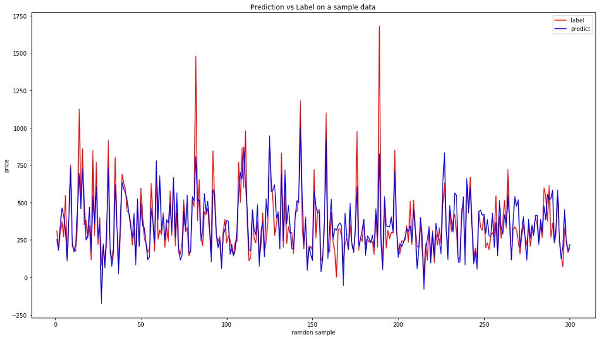

```python
display_size = 300

test_index = random.choices(X_test.index, k=display_size)
Y_label = [Y_test[index] for index in test_index]
Y_predict = model.predict(X_test.loc[test_index])

x = [i+1 for i in range(display_size)]
plt.figure(figsize=(18,10))
plt.plot(x, Y_label, c='red', label='label')
plt.plot(x, Y_predict, c='blue', label='predict')
plt.title('Prediction vs Label on a sample data')
plt.xlabel('ramdon sample')
plt.ylabel('price')
plt.legend()
plt.show()
```

Here we can see that in general, we have a quite good result. However some pic values (very high and very low prices) we are not able to predict well. This pics values may relate to some information we cannot infer from the information from dataset.

For exmaple, the information related to advantage in each location: numbers of school in less than 1km, numbers of metro station nearby, the security information etc.

This information is quite important to the house pricing, but it's not given in the dataset. Which may be the reason we are not able to predict a more accurate result.

### Conclusion & Reflection

In this notebook, we have studied the factors which impact house pricing the most, and a tremendous speed about more than 20% growth in the market.

Finally we build a model to predict Beijing's housing pricing with an RMSE about 123.89, which is not quite perfect result, as some information is not provided as advantage in each location.

So an improvement may be with data mining technology or search information with google map to get this formation and re-train our model.

Another idea comes to me that, split our data randomly may not be a quite good idea, as we want to predict future prices, so we should split data with date:

That is test data should use more recent data, ok here we will try:

```python
housing.sort_values('tradeTime', ascending=False, inplace = True)

housing.shape
```

```
(297985, 19)
```

```python
X_test2 = housing.head(59597).loc[:, housing.columns != 'totalPrice']
Y_test2 = housing.head(59597)['totalPrice']

X_train2 = housing.tail(238388).loc[:, housing.columns != 'totalPrice']
Y_train2 = housing.tail(238388)['totalPrice']
```

```python
model2 = GridSearchCV(pipeline_total, param_grid=parameters, verbose=3, n_jobs=4)
model2.fit(X_train2, Y_train2)
```

```
Fitting 3 folds for each of 6 candidates, totalling 18 fits
```

[output not shown]

```
GridSearchCV(cv='warn', error_score='raise-deprecating',
       estimator=Pipeline(memory=None,
     steps=[('prepare', FeatureUnion(n_jobs=None,
       transformer_list=[('num_pipeline', Pipeline(memory=None,
     steps=[('selector', DataFrameSelector(attribute_name=['Lng', 'Lat', 'square', 'tradeTime', 'livingRoom', 'drawingRoom', 'kitchen', 'bathRoom', 'constructionTime', 'ladderRatio', 'elevato...ing=1.0, loss='epsilon_insensitive', max_iter=1000,
     random_state=None, tol=0.0001, verbose=0))]),
       fit_params=None, iid='warn', n_jobs=4,
       param_grid={'svr__C': [0.1, 0.5, 0.7], 'svr__loss': ['squared_epsilon_insensitive', 'epsilon_insensitive'], 'svr__max_iter': [1000]},
       pre_dispatch='2*n_jobs', refit=True, return_train_score='warn',
       scoring=None, verbose=3)
```

```python
Y_preds2 = model2.predict(X_test2)
mse2 = mean_squared_error(Y_test2, Y_preds2)
```

```python
rmse2 = np.sqrt(mse2)
print("Root-mean-square error is " + str(rmse2))
```

```
Root-mean-square error is 237.82889125677366
```

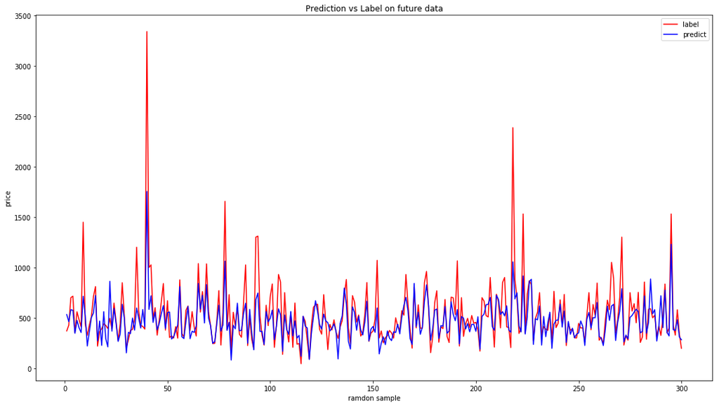

```python
display_size2 = 300

test_index2 = random.choices(X_test2.index, k=display_size2)
Y_label2 = [Y_test2[index] for index in test_index2]
Y_predict2 = model.predict(X_test2.loc[test_index2])

x2 = [i+1 for i in range(display_size2)]
plt.figure(figsize=(18,10))
plt.plot(x2, Y_label2, c='red', label='label')
plt.plot(x2, Y_predict2, c='blue', label='predict')
plt.title('Prediction vs Label on future data')
plt.xlabel('ramdon sample')
plt.ylabel('price')
plt.legend()
plt.show()
```

Compare rmse2 and rmse, 237.83 vs 123.89, we see that the error increased by more than 90%, so predict the future data can be a more challenge problem, the reason maybe that for future, the uncertainty increase, for example the policies may change over time which makes prediction more difficult.